# Seventh Week: Generalized Linear Models

Murder or suicide

Mobin Asri(93101938)

2018-04-27 03:34:19

> با توجه به سوالات مرگ و میر در آمریکا به سوالات زیر پاسخ دهید.

در ابتدا داده مربوط به تمام متغیر ها که در murder_suicide.csv ذخیره شده است را می خوانیم

```r
library(readr)
library(dplyr)
library(ggplot2)
library(readxl)
library(highcharter)
library(tidyr)
library(h2o)
library(ggthemes)
source("../Week7/unbalanced_functions.R")
```

```r
Data=read.csv("../data/murder_suicide.csv")
```

متغیر MannerOfDeath که در واقع کد مربوط به نحوه ی مرگ در آن ذخیره شده است.

این ستون کدشده نیازمند تبدیل به مقدار اسمی آن با استفادهاز متادیتای MannerOfDeath.csv می باشد.

```r
MannerOfDeath_df = read.csv("../data/MannerOfDeath.csv")
colnames(MannerOfDeath_df)[2]="MannerOfDeath"

Data %>% mutate(Code=MannerOfDeath) %>% select(- MannerOfDeath) %>%
  inner_join(MannerOfDeath_df) -> Data
```

از آنجایی که فقط دو level مربوط به قتل و خودکشی در داده ما وجود دارد و سایر level ها با وجود آنکه تعریف شده اند ولی وجود ندارند پس level ها را دوباره تعریف می کنیم.

```r
Manners=as.character(Data$MannerOfDeath)
Data$MannerOfDeath = factor(Manners,levels = unique(Manners))
```

۲. اثر هر یک از متغیرهای جنسیت، نژاد،آموزش، سن و نحوه تدفین را بر مرگ یا خودکشی ارزیابی کنید.

برای بررسی میزان تاثیر جنسیت بر روی خودکشی ابتدا میزان شیوع خدکشی را در بین زنان و مردان به صورت جداگانه محاسبه می کنیم.

```r
Data %>% group_by(Sex) %>%
  summarise(Suicide_n=sum(MannerOfDeath == "Suicide")/n(),
            Homicide_n=sum(MannerOfDeath == "Homicide")/n()) %>%
  filter(!is.na(Sex) ) %>%
  gather(key = MannerOfDeath, value = Percentage, -Sex) -> stat

head(stat)
```

```
## # A tibble: 4 x 3
##      Sex MannerOfDeath Percentage
##   <fctr>         <chr>      <dbl>
## 1      F     Suicide_n  0.7361446
## 2      M     Suicide_n  0.7144264
## 3      F    Homicide_n  0.2638554
## 4      M    Homicide_n  0.2855736
```

```r
stat %>% arrange(Percentage) %>%
  hchart(type="column",hcaes(x=Sex,y=Percentage,group=MannerOfDeath))
```

[interactive chart not shown]

نمودار بالا نشان می دهد که جنسیت تاثیر چندانی در میزان خودکشی ندارد.

ولی تست نسبت فرض صفر برابری نسبت خودکشی به کل مرگ و میر را رد می کند دلیل آن را می توان تعداد زیاد نمونه دانست که تمایل تست به رد کردن فرض صفر را افزایش می دهد.

```r
Data %>% group_by(Sex) %>%
  summarise(Suicide_n=sum(MannerOfDeath == "Suicide"),
            N=n()) -> stat
prop.test(stat$Suicide_n , stat$N)
```

```
##
##  2-sample test for equality of proportions with continuity
##  correction
##
## data:  stat$Suicide_n out of stat$N
## X-squared = 24.044, df = 1, p-value = 9.417e-07
## alternative hypothesis: two.sided
## 95 percent confidence interval:
##  0.01312762 0.03030867
## sample estimates:
##    prop 1    prop 2
## 0.7361446 0.7144264
```

برای بررسی تحصیلات بر روی خوذکشی به روش مختلف تحصیلات افراد طبقه بندی شده است.

ما در این جا از Education2003Revision استفاده می کنیم.

از متادیتای مربوطه برای تبدیل گروه های کدشده استفاده می کنیم.

```r
Education_df = read.csv("../data/Education2003Revision.csv")
colnames(Education_df)[2]="Education"

Data %>% select(Code = Education2003Revision,MannerOfDeath,Id) %>%
  inner_join(Education_df) %>% select(-Code) -> Data_Education
head(Data_Education)
```

```
##   MannerOfDeath Id                             Education
## 1       Suicide 10 high school graduate or GED completed
## 2       Suicide 25    some college credit, but no degree
## 3       Suicide 26                       Master's degree
## 4       Suicide 33 high school graduate or GED completed
## 5       Suicide 41            9 - 12th grade, no diploma
## 6       Suicide 72            9 - 12th grade, no diploma
```

نمودار نسبت ها نشان می دهد که در مقاطع بالاتر نسبت افراد بسیار بیشتری خودکشی کرده اند.

```r
Data_Education %>% group_by(Education) %>%
  summarise(Suicide_n=sum(MannerOfDeath == "Suicide")/n(),
            Homicide_n=sum(MannerOfDeath == "Homicide")/n()) %>%
  filter(!is.na(Education) ) %>%
  gather(key = MannerOfDeath, value = Percentage, -Education) -> stat

stat %>% filter(Education != "Unknown") -> stat
```

```r
table(Data_Education$Education)
```

```
##
##                     8th grade or less
##                                  3079
##            9 - 12th grade, no diploma
##                                  8431
##                      Associate degree
##                                  3448
##                     Bachelor's degree
##                                  5308
##      Doctorate or professional degree
##                                   792
## high school graduate or GED completed
##                                 21756
##                       Master's degree
##                                  1787
##    some college credit, but no degree
##                                  8616
##                               Unknown
##                                  1162
```

```r
stat %>% arrange(Percentage) %>%
  hchart(type="column",hcaes(x=Education,y=Percentage,group=MannerOfDeath))
```

[interactive chart not shown]

برای بررسی تاثیر سن نیز چند طبقه بندی مختلف در داده ها وجود دارد.

ما در این جا از AgeRecord27 استفاده می کنیم. طبقات مربوط به زیر یک سال را یکی می کنیم چرا که اطلاعات چندانی در آنها وجود ندارد.

```r
Age_df = read.csv("../data/AgeRecode27.csv")
colnames(Age_df)[2]="Age"
Age_df$Age=as.character(Age_df$Age)
Age_df$Age[c(1,2)]="Under 1 year"

Age_df$Age=factor(Age_df$Age,levels=Age_df$Age[-1])

head(Age_df)
```

```
##   Code          Age
## 1    1 Under 1 year
## 2    2 Under 1 year
## 3    3       1 year
## 4    4      2 years
## 5    5      3 years
## 6    6      4 years
```

مشابه قبل label های مربوط به سن را استخراج می کنیم.

```r
Data %>% select(Code = Age,MannerOfDeath,Id) %>%
  inner_join(Age_df) %>% select(-Code) -> Data_Age
Data_Age %>% group_by(Age) %>%
  summarise(Suicide_n=sum(MannerOfDeath == "Suicide")/n(),
            Homicide_n=sum(MannerOfDeath == "Homicide")/n()) %>%
  filter(!is.na(Age) ) %>%
  gather(key = MannerOfDeath, value = Percentage, -Age) -> stat

stat %>% filter(Age != "Age not stated") -> stat
```

```r
table(Data_Age$Age)
```

```
##
##       Under 1 year             1 year            2 years
##                337                120                 61
##            3 years            4 years        5 - 9 years
##                 56                 42                 45
##      10 - 14 years      15 - 19 years      20 - 24 years
##                 29                 36                 46
##      25 - 29 years      30 - 34 years      35 - 39 years
##                 73                 94                169
##      40 - 44 years      45 - 49 years      50 - 54 years
##                241                351                501
##      55 - 59 years      60 - 64 years      65 - 69 years
##                634                830                976
##      70 - 74 years      75 - 79 years      80 - 84 years
##               1087               1223               1303
##      85 - 89 years      90 - 94 years      95 - 99 years
##               1247               1282               1196
## 100 years and over     Age not stated
##               1252               1103
```

نمودار نشان می دهد که در سنین جوانی و بزرگسالی تمایل به خودکشی بیشتر از سایر سنین است.

```r
stat %>%
  hchart(type="column",hcaes(x=Age,y=Percentage,group=MannerOfDeath))
```

[interactive chart not shown]

تاثیر نژاد را نیز مشابه روش های قبل بررسی می کنیم.

```r
Race_df = read.csv("../data/Race.csv")
colnames(Race_df)[2]="Race"

Data %>% select(Code = Race,MannerOfDeath,Id) %>%
  inner_join(Race_df) %>% select(-Code) ->  Data_Race
Data_Race %>% group_by(Race) %>%
  summarise(Suicide_n=sum(MannerOfDeath == "Suicide")/n(),
            Homicide_n=sum(MannerOfDeath == "Homicide")/n()) %>%
  filter(!is.na(Race) ) %>%
  gather(key = MannerOfDeath, value = Percentage, -Race) -> stat
```

```r
table(Data_Race$Race)
```

```
##
##                                                               American Indian (includes Aleuts and Eskimos)
##                                                                                                         781
##                                                                                                Asian Indian
##                                                                                                         190
##                                                                                                       Black
##                                                                                                       10582
##                                                                                                     Chinese
##                                                                                                         263
## Combined other Asian or Pacific Islander, includes codes 18-68 for areas that do not report them separately
##                                                                                                         116
##                                                                                                    Filipino
##                                                                                                         184
##                                                                                                   Guamanian
##                                                                                                          10
##                                                                           Hawaiian (includes Part-Hawaiian)
##                                                                                                          10
##                                                                                                    Japanese
##                                                                                                          85
##                                                                                                      Korean
##                                                                                                         215
##                                                                             Other Asian or Pacific Islander
##                                                                                                           0
##                                              Other Asian or Pacific Islander in areas reporting codes 18-58
##                                                                                                         307
##                                                                                                 Other races
##                                                                                                           0
##                                                                                                      Samoan
##                                                                                                          24
##                                                                                                  Vietnamese
##                                                                                                         139
##                                                                                                       White
##                                                                                                       47073
```

نمودار زیر نمودار نسبت ها را نشان می دهد و اگر تاثیر تعداد را نیز در نظر بگیریم نژاد سیاه و سفید بیشترین اطلاعات را هم از نظر نسبت بالای کشته شدن بر اثر قتل و هم از نظر تعداد بالای افراد را شامل می شود.

```r
stat %>% arrange(Percentage) %>%
  hchart(type="column",hcaes(x=Race,y=Percentage,group=MannerOfDeath))
```

[interactive chart not shown]

نمودار زیر تعداد را نشان می دهد که اثباتی بر ادعای فوق می باشد.

```r
Data_Race %>% group_by(Race) %>%
  summarise(Suicide_n=sum(MannerOfDeath == "Suicide"),
            Homicide_n=sum(MannerOfDeath == "Homicide")) %>%
  filter(!is.na(Race) ) %>%
  gather(key = MannerOfDeath, value = Count, -Race) -> stat

stat %>% arrange(Count) %>%
  hchart(type="column",hcaes(x=Race,y=Count,group=MannerOfDeath))
```

[interactive chart not shown]

تاثیر نحوه ی تدفین بر روی قتل یا خودکشی مشابه متغیر های قبلی بررسی می شود.

```r
Disposition_df = read.csv("../data/MethodOfDisposition.csv")
colnames(Disposition_df)[2]="MethodOfDisposition"

Data %>% select(Code = MethodOfDisposition,MannerOfDeath,Id) %>%
  inner_join(Disposition_df) %>% select(-Code) -> Data_Dispo
Data_Dispo %>% group_by(MethodOfDisposition) %>%
  summarise(Suicide_n=sum(MannerOfDeath == "Suicide")/n(),
            Homicide_n=sum(MannerOfDeath == "Homicide")/n()) %>%
  filter(!is.na(MethodOfDisposition) ) %>%
  gather(key = MannerOfDeath, value = Percentage, -MethodOfDisposition) -> stat
```

نمودار زیر نشان می دهد که درصد بالایی از افرادی که با تشریفات دفن شده اند خودکشی کرده اند.

```r
stat %>% arrange(Percentage) %>%
  hchart(type="column",
         hcaes(x=MethodOfDisposition,y=Percentage,group=MannerOfDeath))
```

[interactive chart not shown]

۳. با استفاده از مدل رگرسیون لاجستیک یک مدل به داده ها برازش دهید و سپس آن را نقص یابی کنید.

سه متغیر آموزش ، نژاد و سن را انتخاب می کنیم برای فیت کردن GLM و در کنار آن یک متغیر کمکیبه عنوان جواب واقعی تحت عنوان Suicide ایجاد می کنیم.

یکی از کار هایی که می توان انجام داد تغییر دادن level های مربوط به نژاد و سن است تا آن هایی که pvalue زیاد دارند راحذف کرد و از آنجایی که ضریب فیت شده برای این پارامتر های با pvalue زیاد معمولا کم هستند تاثیر زیادی در دقت مدل نخواهد داشت.

```r
Data_Education %>%
  inner_join(Data_Race) %>%
  inner_join(Data_Age) %>%
  filter(!is.na(Education) & !is.na(Race) & !is.na(Age) ) %>%
  mutate(Suicide = ifelse(MannerOfDeath == "Suicide" , 1 , 0))-> Reduced_Data
head(Reduced_Data)
```

```
##   MannerOfDeath Id                             Education
## 1       Suicide 10 high school graduate or GED completed
## 2       Suicide 25    some college credit, but no degree
## 3       Suicide 41            9 - 12th grade, no diploma
## 4       Suicide 72            9 - 12th grade, no diploma
## 5       Suicide 93 high school graduate or GED completed
## 6       Suicide 97    some college credit, but no degree
##                                            Race           Age Suicide
## 1                                         White 85 - 89 years       1
## 2                                         White 70 - 74 years       1
## 3 American Indian (includes Aleuts and Eskimos) 85 - 89 years       1
## 4 American Indian (includes Aleuts and Eskimos) 80 - 84 years       1
## 5 American Indian (includes Aleuts and Eskimos) 65 - 69 years       1
## 6                                         White 80 - 84 years       1
```

```r
Reduced_Data %>%
  glm(Suicide ~ Education + Race + Age,
      data= ., family = "binomial") -> mylogit

summary(mylogit)
```

```
##
## Call:
## glm(formula = Suicide ~ Education + Race + Age, family = "binomial",
##     data = .)
##
## Deviance Residuals:
##     Min       1Q   Median       3Q      Max
## -2.5280  -0.6198   0.4866   0.8055   2.9547
##
## Coefficients:
##                                                                                                                   Estimate
## (Intercept)                                                                                                     -1.702e+01
## Education9 - 12th grade, no diploma                                                                              4.571e-01
## EducationAssociate degree                                                                                        1.900e+00
## EducationBachelor's degree                                                                                       2.298e+00
## EducationDoctorate or professional degree                                                                        1.771e+01
## Educationhigh school graduate or GED completed                                                                   1.060e+00
## EducationMaster's degree                                                                                         3.427e+00
## Educationsome college credit, but no degree                                                                      1.766e+00
## EducationUnknown                                                                                                 5.105e-01
## RaceAsian Indian                                                                                                 2.795e-01
## RaceBlack                                                                                                       -2.340e+00
## RaceChinese                                                                                                      1.971e-01
## RaceCombined other Asian or Pacific Islander, includes codes 18-68 for areas that do not report them separately -1.099e-03
## RaceFilipino                                                                                                     2.791e-01
## RaceGuamanian                                                                                                    1.661e+01
## RaceHawaiian (includes Part-Hawaiian)                                                                           -7.831e-01
## RaceJapanese                                                                                                     1.137e+00
## RaceKorean                                                                                                       3.748e-01
## RaceOther Asian or Pacific Islander in areas reporting codes 18-58                                               2.709e-01
## RaceSamoan                                                                                                       7.059e-02
## RaceVietnamese                                                                                                  -3.310e-01
## RaceWhite                                                                                                        1.717e-01
## Age1 year                                                                                                       -8.485e-02
## Age2 years                                                                                                      -2.544e-02
## Age3 years                                                                                                      -1.683e-01
## Age4 years                                                                                                      -2.213e-02
## Age5 - 9 years                                                                                                  -1.245e-01
## Age10 - 14 years                                                                                                -3.776e-02
## Age15 - 19 years                                                                                                 1.501e+01
```

[output cut: 205 more lines]

```
## Age85 - 89 years
## Age90 - 94 years
## Age95 - 99 years
## Age100 years and over
## AgeAge not stated
## ---
## Signif. codes:  0 '***' 0.001 '**' 0.01 '*' 0.05 '.' 0.1 ' ' 1
##
## (Dispersion parameter for binomial family taken to be 1)
##
##     Null deviance: 18108  on 13083  degrees of freedom
## Residual deviance: 12817  on 13037  degrees of freedom
## AIC: 12911
##
## Number of Fisher Scoring iterations: 16
```

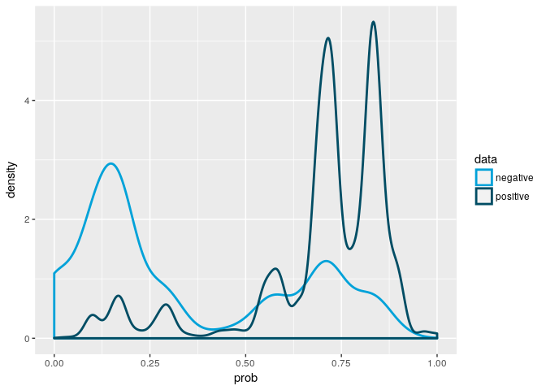

```r
Reduced_Data = Reduced_Data %>% mutate(prob = fitted(mylogit))

ggplot( Reduced_Data, aes( prob, col = as.factor(Suicide))) +
  geom_density( size = 1 ) +
  scale_color_economist( name = "data", labels = c( "negative", "positive" ) )
```

```r
Threshold=0.5
Reduced_Data = Reduced_Data  %>%  mutate(pred= prob>Threshold)

table=table(Reduced_Data[,c("Suicide","pred")])
table
```

```
##        pred
## Suicide FALSE TRUE
##       0  4136 2089
##       1   791 6068
```

۴. با استفاده از سه نمودار خروجی مدل را نسبت به داده واقعی ارزیابی کنید.

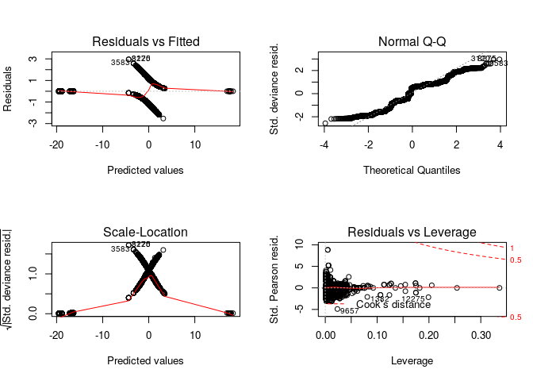

```r
par(mfrow=c(2,2))
plot(mylogit)
```

۵. ابتدا ۲۰ درصد داده را به صورت تصادفی به عنوان تست در نظر بگیرید. مدل را با استفاده از ۸۰ درصد باقی مانده برازش دهید. با استفاده از پارامتر قطع ۰.۵ نتایج را برای داده تست پیش بینی کنید. سپس کمیت های زیر را محاسبه کنید.

- P: positive samples
- N: negative samples
- TP: true positive TP (eqv. with hit)
- TN: true negative (eqv. with correct rejection)
- FP: false positive (eqv. with false alarm, Type I error)
- FN: false negative (eqv. with miss, Type II error)
- Accuracy (ACC) ACC = (TP+TN)/(P+T)
- False positive rate (FPR): 1- TN/N
- True positive rate (TPR): TP/P

مشابه آنچه در کلاس گفته شد نمایشی از چهار کمیت TN, TP,FP,FN به همراه داده ها رسم نمایید.

```r
Ns=nrow(Data)
idx_Train=sample(seq(Ns),size = floor(0.8 * Ns))
idx_Test=setdiff(seq(Ns),idx_Train)

Ids_Train=Data$Id[idx_Train]
Ids_Test=Data$Id[idx_Test]

Reduced_Data %>% filter(Id %in% Ids_Train)-> Data_Train
Reduced_Data %>% filter(Id %in% Ids_Test)-> Data_Test

Data_Train %>%
  glm(Suicide ~ Education + Race +Age,
      data= ., family = "binomial") -> mylogit
summary(mylogit)
```

```
##
## Call:
## glm(formula = Suicide ~ Education + Race + Age, family = "binomial",
##     data = .)
##
## Deviance Residuals:
##     Min       1Q   Median       3Q      Max
## -2.4043  -0.6153   0.4702   0.7963   2.8948
##
## Coefficients:
##                                                                                                                   Estimate
## (Intercept)                                                                                                      -17.06816
## Education9 - 12th grade, no diploma                                                                                0.45154
## EducationAssociate degree                                                                                          1.95604
## EducationBachelor's degree                                                                                         2.45665
## EducationDoctorate or professional degree                                                                         17.75188
## Educationhigh school graduate or GED completed                                                                     1.08416
## EducationMaster's degree                                                                                           2.64106
## Educationsome college credit, but no degree                                                                        1.79417
## EducationUnknown                                                                                                   0.73995
## RaceAsian Indian                                                                                                   0.14064
## RaceBlack                                                                                                         -2.42684
## RaceChinese                                                                                                        0.57670
## RaceCombined other Asian or Pacific Islander, includes codes 18-68 for areas that do not report them separately    0.12039
## RaceFilipino                                                                                                       0.41675
## RaceGuamanian                                                                                                     16.56152
## RaceHawaiian (includes Part-Hawaiian)                                                                             -0.84819
## RaceJapanese                                                                                                       1.02064
## RaceKorean                                                                                                         0.25138
## RaceOther Asian or Pacific Islander in areas reporting codes 18-58                                                 0.17666
## RaceSamoan                                                                                                         0.03489
## RaceVietnamese                                                                                                    -0.28838
## RaceWhite                                                                                                          0.12736
## Age1 year                                                                                                          0.01257
## Age2 years                                                                                                        -0.05588
## Age3 years                                                                                                        -0.05235
## Age4 years                                                                                                         0.04507
## Age5 - 9 years                                                                                                    -0.09313
## Age10 - 14 years                                                                                                  -0.02235
## Age15 - 19 years                                                                                                  15.32030
```

[output cut: 205 more lines]

```
## Age85 - 89 years
## Age90 - 94 years
## Age95 - 99 years
## Age100 years and over
## AgeAge not stated
## ---
## Signif. codes:  0 '***' 0.001 '**' 0.01 '*' 0.05 '.' 0.1 ' ' 1
##
## (Dispersion parameter for binomial family taken to be 1)
##
##     Null deviance: 14427  on 10428  degrees of freedom
## Residual deviance: 10082  on 10382  degrees of freedom
## AIC: 10176
##
## Number of Fisher Scoring iterations: 16
```

```r
Data_Train$prob = predict( mylogit , newdata = Data_Train, type = "response" )

Data_Test$prob = predict( mylogit , newdata = Data_Test, type = "response" )
```

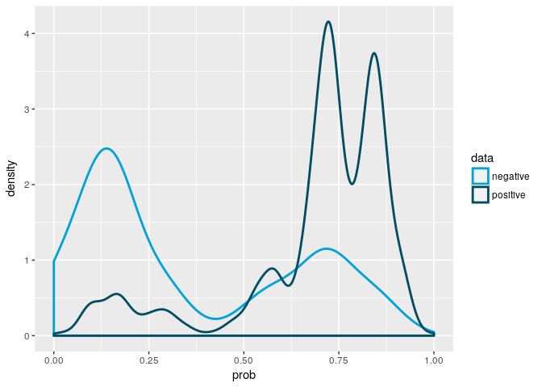

```r
ggplot( Data_Test, aes( prob, color = as.factor(Suicide))) +
  geom_density( size = 1 )+
  scale_color_economist( name = "data", labels = c( "negative", "positive" ) )
```

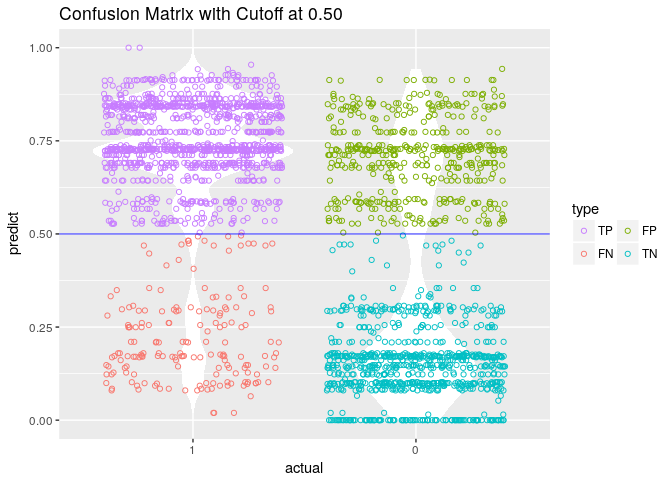

```r
cm_info = ConfusionMatrixInfo( data = Data_Test, predict = "prob",
                               actual = "Suicide", cutoff = .5 )
cm_info$plot
```

```r
table=table(Data_Test[,c("Suicide","pred")])
table
```

```
##        pred
## Suicide FALSE TRUE
##       0   836  459
##       1   174 1186
```

```r
TP=table[2,2]
TN=table[1,1]
FP=table[1,2]
FN=table[2,1]

P=TP+FP
N=TN+FN

#Accuracy
ACC = (TP+TN)/(P+N)
#False positive rate
FPR = FP/N
#True positive rate
TPR = TP/P
```

```r
ACC
```

```
## [1] 0.7615819
```

```r
FPR
```

```
## [1] 0.4544554
```

```r
TPR
```

```
## [1] 0.7209726
```

۶. نمودار صحت مدل (accuracy) را بر حسب مقادیر مختلف قطع برای داده تست رسم نمایید. کدام پارامتر قطع بالاترین صحت را در پیش بینی داراست؟

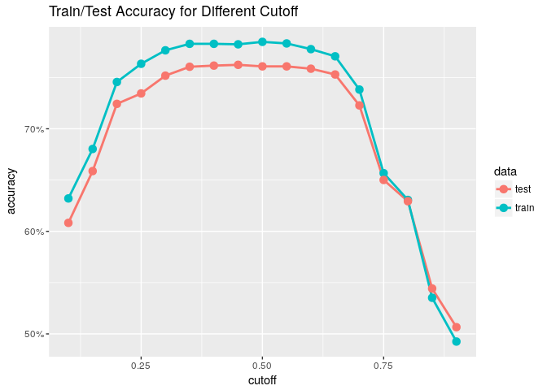

```r
accuracy_info = AccuracyCutoffInfo( train = Data_Train, test = Data_Test,
                                    predict = "prob", actual = "Suicide" )
accuracy_info$plot
```

۷. نمودار ROC را برای داده های قسمت قبل رسم نمایید. همچنین نقطه مربوط به بهترین پارامتر قطع را مشخص نمایید.

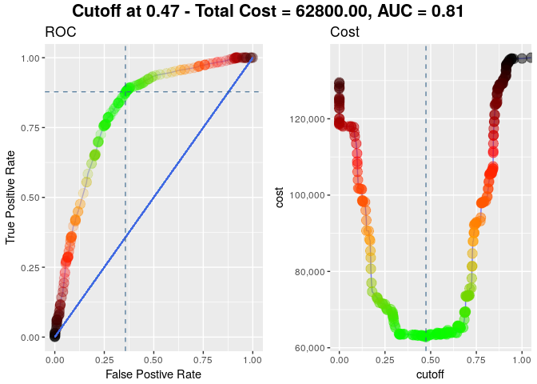

```r
cost_fp = 100;cost_fn = 100
roc_info = ROCInfo( data = cm_info$data, predict = "predict",
                    actual = "actual", cost.fp = cost_fp, cost.fn = cost_fn )
grid.draw(roc_info$plot)
```

***

۸. با قرار دادن کمیت nfolds = 5 و با استفاده از H20 مدل مساله را بسازید و نتیجه حاصل را ارزیابی کنید.

```r
h2o.init()
```

[output not shown]

```r
hData=as.h2o(Reduced_Data)
chglm = h2o.glm(y = "Suicide", x= c("Race","Age","Education"),
                training_frame = hData, family="binomial",nfolds = 5)
```

پارامتر هایی که می توان آن ها را در نظر گرفت

میانگین خطاهای مربوط به residuals

MSE: 0.160463

مساحت زیر نمودار ROC

AUC: 0.8302241

و دقت

```r
summary(chglm)
```

```
## Model Details:
## ==============
##
## H2OBinomialModel: glm
## Model Key:  GLM_model_R_1524778021736_109
## GLM Model: summary
##     family  link                                regularization
## 1 binomial logit Elastic Net (alpha = 0.5, lambda = 2.363E-4 )
##   number_of_predictors_total number_of_active_predictors
## 1                         49                          42
##   number_of_iterations training_frame
## 1                    6   Reduced_Data
##
## H2OBinomialMetrics: glm
## ** Reported on training data. **
##
## MSE:  0.160463
## RMSE:  0.4005783
## LogLoss:  0.4932441
## Mean Per-Class Error:  0.2277495
## AUC:  0.8302241
## Gini:  0.6604481
## R^2:  0.3566375
## Residual Deviance:  12907.21
## AIC:  12993.21
##
## Confusion Matrix (vertical: actual; across: predicted) for F1-optimal threshold:
##           0    1    Error         Rate
## 0      4023 2202 0.353735   =2202/6225
## 1       698 6161 0.101764    =698/6859
## Totals 4721 8363 0.221645  =2900/13084
##
## Maximum Metrics: Maximum metrics at their respective thresholds
##                         metric threshold    value idx
## 1                       max f1  0.374077 0.809486 280
## 2                       max f2  0.206526 0.875047 319
## 3                 max f0point5  0.620446 0.780519 203
## 4                 max accuracy  0.524438 0.779731 250
## 5                max precision  0.906304 1.000000   0
## 6                   max recall  0.027483 1.000000 388
```

[output cut: 100 more lines]

```
## ---
##                                                                                                               names
## 44                                                                                                     Race.Chinese
## 45 Race.Combined other Asian or Pacific Islander, includes codes 18-68 for areas that do not report them separately
## 46                                                                                                   Race.Guamanian
## 47                                                                           Race.Hawaiian (includes Part-Hawaiian)
## 48                                                                                                    Race.Japanese
## 49                                                                                                      Race.Samoan
##    coefficients sign
## 44     0.000000  POS
## 45     0.000000  POS
## 46     0.000000  POS
## 47     0.000000  POS
## 48     0.000000  POS
## 49     0.000000  POS
```

۹. آیا ما میتوانیم سرویسی به قضات ارایه کنیم تا با استفاده از اطلاعات مرگ بتوانند موارد مشکوک به قتل را از خودکشی تفکیک دهند؟

اگر هم این مدل های آماری قابلیت ارایه شدن به قضات را داشته باشند هیچ گاه نخواهند توانست قابل اطمینان باشند چرا که جرم های انسانی از قواعد بسیار پیچیده پیروی می کنند که مدل های آماری در برابر انها بسیار ساده هستند. صرفا می توان به عنوان کمک به قضات ارایه شوند تا نشان دهند که تجربه های گذشته درباره ی پرونده های مختلف چه پیش بینی می کند.